# Reinforcement-Learning

## Reinforcement Learning: Markov Decision Processes

### 1. Objective:

The purpose of this project is to explore the 3 different reinforcement learning algorithms and analyze their performance on two different discrete Markov Decision Processes. Value iteration, Policy Iteration and Q Learning algorithms are implemented for two MDPs, one with small number of states while other with large number of states. These MDPs also differ in terms of reward function and transition models. Results of these algorithms are then analyzed and compared on various performance metrics. These performance metrics include similarities in the policies generate, convergence rate and runtimes.

### 2. Markov Decision Process

Markov Decision Process (MDP) provides the mathematical framework to model the decision-making process for deterministic as well as stochastic problems. MDPs are particularly useful to solve real world problems where outcome of actions performed by an agent is partially random and partially controlled by the agent. These decision making problems can ne solved using MDPs only if the Markov property is followed which states that the future of the system state depends only on the current state and not on the any sequence of past states.

A Markov Decision Process is a tuple <S,A,P,R,γ>

- S = finite set of states
- A = finite set of actions
- P = state transition probability matrix: P<sub>ss'</sub> = P[S<sub>t+1</sub>=s' | S<sub>t</sub>=s, A<sub>t</sub>=a]
- R = reward function: R<sub>s</sub> = E[R<sub>t+1</sub> | S<sub>t</sub> = s, A<sub>t</sub>=a]
- γ = discount factor

To solve the MDPs we identify the optimal Policy π which defines the behavior of an agent and it is a distribution over actions given states:

π(a|s) = P[A<sub>t</sub>=a | S<sub>t</sub>=s]

It is also assumed that MDPs are stationary which means policy function only depend on the given state and it is not affected by any other factor. To avoid infinite runs of cyclic Markov process and to represent uncertainty about the future rewards are discounted.

The state-value function v<sub>π</sub>(s) tells us how good it is to be in a given state. It gives us expected return starting from the state s, and then following policy π.

v<sub>π</sub>(s) = E<sub>π</sub>[G<sub>t</sub> | S<sub>t</sub>=s]

The action-value function q<sub>π</sub>(s,a) tells us what action to take given the agent is in particular state. It gives the expected return starting from state s, taking action a, and then following policy π.

q<sub>π</sub>(s,a) = E<sub>π</sub>[G<sub>t</sub> | S<sub>t</sub>=s, A<sub>t</sub>=a]

Using **Bellman Equation** state-value function and action-value function can again be further decomposed into immediate reward plus discounted value of successor state

v<sub>π</sub>(s) = E<sub>π</sub>[R<sub>t+1</sub> + γv<sub>π</sub>(S<sub>t+1</sub>) | S<sub>t</sub>=s]

q<sub>π</sub>(s,a) = E<sub>π</sub>[R<sub>t+1</sub> + γq<sub>π</sub>(S<sub>t+1</sub>,A<sub>t+1</sub>) | S<sub>t</sub>=s, A<sub>t</sub>=a]

### 3. Algorithms Implemented & Evaluation Criterion

#### 3.1 Value Iteration

This algorithm is also known as backward induction and it uses Bellman Equations to repeatedly update the estimated value function until optimal value function v(s) is found. The algorithm randomly initializes v(s) and iteratively updates the q(s, a) and v(s) values until they converges. Value iteration is guaranteed to converge to the optimal values. Below is the Value Iteration algorithm [1]

[figure not shown]

#### 3.2 Policy Iteration

[figure not shown]

#### 3.3 Q Learning

Q learning is model free algorithm. Unlike the Value and Policy iteration models, Q Learning drive the optimal policy without explicitly learning transitions and value gained. Q Learning do not depend on the knowledge of the underlying uncertainties in transition and associated rewards. Q Learning algorithm allows agent to explore the environment by implementing random actions to explore the environment. Below is the Q Learning algorithm [2]

[figure not shown]

#### 3.4 Packages Used

MDP toolbox provides classes and functions for the resolution of discrete-time Markov Decision Processes. To implement three reinforcement learning algorithms, fork of MDPToolBox is used. Frozen lake environment provided by OpenAI Gym is used for Grid World problem whereas example Forest Manage problem available in the MDP Toolbox is used as second MDP problem. Other standard packages such as pandas, numpy, matplotlib and seaborn are used in this project.

MDP Toolbox: https://github.com/hiive/hiivemdptoolbox  
OpenAi Gym: https://github.com/openai/gym/wiki/FrozenLake-v0

#### 3.5 Implementation Steps & Evaluation Criterion

```python
#Packages Used
import gym
import time
import random
import numpy as np
import pandas as pd
import matplotlib.pyplot as plt
import seaborn as sns
from gym.envs.toy_text.frozen_lake import generate_random_map
from hiive.mdptoolbox.mdp import PolicyIteration, ValueIteration, QLearning, PolicyIterationModified
from hiive.mdptoolbox.example import forest
```

### 4. Problems Solved

#### 4.1. Frozen Lake (Grid World Problem)

Agent can take four actions, move **left (0), down (1), right (2) or up (3)**. Like the real world frozen lake has slippery surface, this environment is also stochastic. That means if agent tries to move up, there is only 33% chance that it will actually move up whereas 33% chance for each left or right movement.

**Why this is an interesting problem?** Although grid world problems look abstract but closely resemble some real-world problems like robotic automation for order fulfillment process in the warehouse or a distribution centers. For example, robots at warehouse must navigate through aisles avoiding fixed structures such as pillar etc. in their path. The ultimate goal is to specific location to retrieve an item. Stochastic nature of grid world problem also represents real world scenarios where floor is slippery or motor that drives the robot is not accurately calibrated. It will be interesting to see how algorithms behave for different values hyper parameters such discounted rate, stopping criteria etc. As warehouse can be very large. it will also be interesting to see how size of the problem affects the performance of the algorithms.

Create frozen lake environment

```python
flsz = 6
flrmap = generate_random_map(size=flsz, p=0.85)
flenv = gym.make("FrozenLake-v0", desc=flrmap, is_slippery = True)
flenv.reset()
flenv.render()

flstates = flenv.observation_space.n
flactions = flenv.action_space.n

fltrans = np.zeros((flactions, flstates, flstates))
flrewards = np.zeros((flstates, flactions))

for state in flenv.env.P:
    for action in flenv.env.P[state]:
        for opt in flenv.env.P[state][action]:
            fltrans[action][state][opt[1]] += opt[0]
            flrewards[state][action] += opt[2]
```

```
SFFFFH
HFFFFH
HFFHFF
HFFFFF
FFFFFF
FFFFFG
```

#### 4.2. Forest Management (Non-Grid World Problem)

Forest management has two objectives, first is to maintain the old forest for wildlife conservation and second objective is to generate profit by cutting the wood. With these two objectives in mind, each year decision is taken to perform one of two actions: **Wait** or **Cut**. Each year there is a probability **p** that burns down the forest. State space **S** represents the number of classes of the trees. Once the trees reach to the oldest states there is a rewards **r1** and **r2** associated actions Wait and Cut respectively. For this project wildlife conservation has higher reward of 4 as compared to cutting the forest which has reward of 2. Probability of wildfire is 10% each year. Tress are divided into 500 classes where each class represent the age of trees.

**Why this is an interesting problem?** Forest management is a real world challenge in current environment where one hand wildlife and their habitats are lost to indiscriminate forest cutting and on the other hand wildfires are burning down the large areas of forest which leads to loss of wood which could have cut down for its value. Uncertainty of wildfire represented as **p** in this problem and large set of states makes this problem very interesting. For such large number of states, it will be interesting to see if Q Learning performs better than Value Iteration and Policy Iteration.

Create environment for forest management problem

```python
fmsz = 500
fmtrans, fmrewards = forest(S=fmsz)
```

### 5. Value Iteration and Policy Iteration

#### 5.1.1 Frozen Lake - Optimal value of Discount Factor (Gamma)

Notice that as value of gamma is closer to, number of iterations and run tine for Value Iteration increases exponentially. When gamma is closer to 1, policy iteration converges in much lesser iterations and faster than value iteration. Policy iteration required fewer iterations because it performed the maximization over the action set at each iteration of the outer loop. Both Value Iteration and Policy Iteration generated exact same rewards over the range of gamma values.

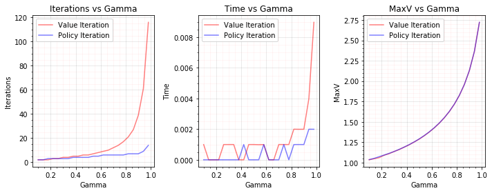

```python
vistats = []
pistats = []
fig, axs = plt.subplots(nrows=1, ncols=3, figsize=(10,4));

gammas = np.arange(0.1, 0.99, 0.04)

for gamma in gammas:
    vi = ValueIteration(fltrans, flrewards, gamma)
    vi.run()
    time = vi.time
    maxV = np.amax(vi.V)
    iters = vi.iter
    vistats.append(['VI', flsz, gamma, time, maxV, iters])

    pi = PolicyIterationModified(fltrans, flrewards, gamma)
    pi.run()
    time = pi.time
    maxV = np.amax(pi.V)
    iters = pi.iter
    pistats.append(['PI', flsz, gamma, time, maxV, iters])

dfvi = pd.DataFrame(vistats, columns=['Type', 'Size', 'Gamma',  'Time', 'MaxV',  'Iterations'])
dfpi = pd.DataFrame(pistats, columns=['Type', 'Size', 'Gamma',  'Time', 'MaxV',  'Iterations'])

sns.lineplot(dfvi['Gamma'], dfvi['Iterations'], linestyle='-.', label = "Value Iteration", ax=axs[0], alpha=0.5, color='red')
sns.lineplot(dfpi['Gamma'], dfpi['Iterations'], linestyle='--', label = "Policy Iteration", ax=axs[0], alpha=0.5, color='blue')
axs[0].set_title('Iterations vs Gamma')

sns.lineplot(dfvi['Gamma'], dfvi['Time'], linestyle='-.', label = "Value Iteration", ax=axs[1], alpha=0.5, color='red')
sns.lineplot(dfpi['Gamma'], dfpi['Time'], linestyle='--', label = "Policy Iteration", ax=axs[1], alpha=0.5, color='blue')
axs[1].set_title('Time vs Gamma')

sns.lineplot(dfvi['Gamma'], dfvi['MaxV'], linestyle='-.', label = "Value Iteration", ax=axs[2], alpha=0.5, color='red')
sns.lineplot(dfpi['Gamma'], dfpi['MaxV'], linestyle='--', label = "Policy Iteration", ax=axs[2], alpha=0.5, color='blue')
axs[2].set_title('MaxV vs Gamma')

for ax in axs.flat:
    ax.legend(loc='best')
    ax.minorticks_on()
    ax.grid(b=True, which='major', color='k', linestyle='-', alpha=0.1)
    ax.grid(b=True, which='minor', color='r', linestyle='-', alpha=0.05)
fig.tight_layout()
```

#### 5.1.2 Forest Management - Optimal value of Discount Factor (Gamma)

Although forest management problem has very high number of states results were like results of frozen lake. Only exception was the run time for policy iteration increased with the increase in the value of gamma. This is because of the complexity and size of the problem. In this problem also value iteration took more iterations as compared to policy iteration algorithm. Again the reward generated by both algorithms matched for the range of gamma values.

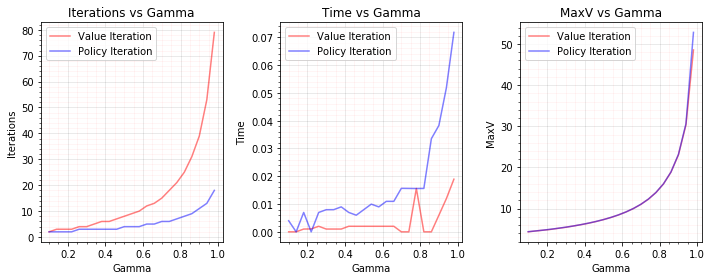

```python
vistats = []
pistats = []
fig, axs = plt.subplots(nrows=1, ncols=3, figsize=(10,4));

gammas = np.arange(0.1, 0.99, 0.04)

for gamma in gammas:
    vi = ValueIteration(fmtrans, fmrewards, gamma)
    vi.run()
    time = vi.time
    maxV = np.amax(vi.V)
    iters = vi.iter
    vistats.append(['VI', fmsz, gamma, time, maxV, iters])


    pi = PolicyIterationModified(fmtrans, fmrewards, gamma)
    pi.run()
    time = pi.time
    maxV = np.amax(pi.V)
    iters = pi.iter
    pistats.append(['PI', fmsz, gamma, time, maxV, iters])

dfvi = pd.DataFrame(vistats, columns=['Type', 'Size', 'Gamma',  'Time', 'MaxV',  'Iterations'])
dfpi = pd.DataFrame(pistats, columns=['Type', 'Size', 'Gamma',  'Time', 'MaxV',  'Iterations'])

sns.lineplot(dfvi['Gamma'], dfvi['Iterations'], linestyle='-.', label = "Value Iteration", ax=axs[0], alpha=0.5, color='red')
sns.lineplot(dfpi['Gamma'], dfpi['Iterations'], linestyle='--', label = "Policy Iteration", ax=axs[0], alpha=0.5, color='blue')
axs[0].set_title('Iterations vs Gamma')

sns.lineplot(dfvi['Gamma'], dfvi['Time'], linestyle='-.', label = "Value Iteration", ax=axs[1], alpha=0.5, color='red')
sns.lineplot(dfpi['Gamma'], dfpi['Time'], linestyle='--', label = "Policy Iteration", ax=axs[1], alpha=0.5, color='blue')
axs[1].set_title('Time vs Gamma')

sns.lineplot(dfvi['Gamma'], dfvi['MaxV'], linestyle='-.', label = "Value Iteration", ax=axs[2], alpha=0.5, color='red')
sns.lineplot(dfpi['Gamma'], dfpi['MaxV'], linestyle='--', label = "Policy Iteration", ax=axs[2], alpha=0.5, color='blue')
axs[2].set_title('MaxV vs Gamma')


for ax in axs.flat:
    ax.legend(loc='best')
    ax.minorticks_on()
    ax.grid(b=True, which='major', color='k', linestyle='-', alpha=0.1)
    ax.grid(b=True, which='minor', color='r', linestyle='-', alpha=0.05)
fig.tight_layout()
```

#### 5.2 Optimal value of stopping criterion (Epsilon)

In this step the both Value Iteration and Policy Iteration algorithms were implemented for range of stopping criterion starting from 0.001 till 0.05. Value if this epsilon defines the stopping criteria for both of these algorithms. At each iteration Value function calculates the delta and if this delta is lesser than value of epsilon, algorithm stops. If value of epsilon is too low, then algorithms will take too long to converge on the other hand if value of epsilon is too high then algorithms will converge too quickly without optimal policy.

##### 5.2.1 Frozen Lake - Optimal value of stopping criterion (Epsilon)

From the graphs of the frozen lake problem it can see that number of iteration and runtime increase as value of epsilon closes to 0. Also, the Max Value decreases with increase in the value of epsilon. Although value iteration is simple it is computationally heavy hence higher runtime. Notice that Value iteration takes more time as well as iterations but overall performance in terms of Max Value is similar.

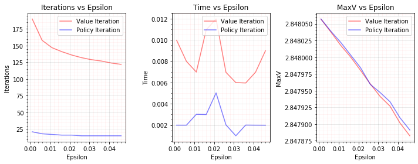

```python
vistats = []
pistats = []
fig, axs = plt.subplots(nrows=1, ncols=3, figsize=(10,4));

gamma = 0.99
epsilons = np.arange(0.001,0.05, 0.005)

for epsilon in epsilons:
    vi = ValueIteration(fltrans, flrewards, gamma, epsilon=epsilon)
    vi.run()
    time = vi.time
    maxV = np.amax(vi.V)
    iters = vi.iter
    vistats.append(['VI', flsz, epsilon, time, maxV, iters])


    pi = PolicyIterationModified(fltrans, flrewards, gamma, epsilon=epsilon)
    pi.run()
    time = pi.time
    maxV = np.amax(pi.V)
    iters = pi.iter
    pistats.append(['PI', flsz, epsilon, time, maxV, iters])

dfvi = pd.DataFrame(vistats, columns=['Type', 'Size', 'Epsilon',  'Time', 'MaxV', 'Iterations'])
dfpi = pd.DataFrame(pistats, columns=['Type', 'Size', 'Epsilon',  'Time', 'MaxV', 'Iterations'])

sns.lineplot(dfvi['Epsilon'], dfvi['Iterations'], linestyle='-.', label = "Value Iteration", ax=axs[0], alpha=0.5, color='red')
sns.lineplot(dfpi['Epsilon'], dfpi['Iterations'], linestyle='--', label = "Policy Iteration", ax=axs[0], alpha=0.5, color='blue')
axs[0].set_title('Iterations vs Epsilon')

sns.lineplot(dfvi['Epsilon'], dfvi['Time'], linestyle='-.', label = "Value Iteration", ax=axs[1], alpha=0.5, color='red')
sns.lineplot(dfpi['Epsilon'], dfpi['Time'], linestyle='--', label = "Policy Iteration", ax=axs[1], alpha=0.5, color='blue')
axs[1].set_title('Time vs Epsilon')

sns.lineplot(dfvi['Epsilon'], dfvi['MaxV'], linestyle='-.', label = "Value Iteration", ax=axs[2], alpha=0.5, color='red')
sns.lineplot(dfpi['Epsilon'], dfpi['MaxV'], linestyle='--', label = "Policy Iteration", ax=axs[2], alpha=0.5, color='blue')
axs[2].set_title('MaxV vs Epsilon')

for ax in axs.flat:
    ax.legend(loc='best')
    ax.minorticks_on()
    ax.grid(b=True, which='major', color='k', linestyle='-', alpha=0.1)
    ax.grid(b=True, which='minor', color='r', linestyle='-', alpha=0.05)
fig.tight_layout()
```

##### 5.2.2 Forest Management - Optimal value of stopping criterion (Epsilon)

For forest management problem, observations are interesting. Although number of iterations required to converge for value iteration are more than that of policy iteration, surprisingly execution time for policy iteration algorithm is higher than that of value iteration. Also the max value for policy iteration is same irrespective of epsilon. For value iteration Max V slightly decreases with increase in epsilon.

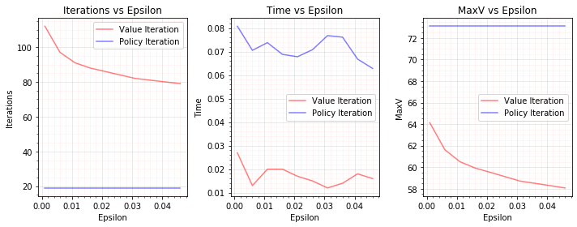

```python
vistats = []
pistats = []
fig, axs = plt.subplots(nrows=1, ncols=3, figsize=(10,4));

gamma = 0.99
epsilons = np.arange(0.001,0.05, 0.005)

for epsilon in epsilons:
    vi = ValueIteration(fmtrans, fmrewards, gamma, epsilon=epsilon)
    vi.run()
    time = vi.time
    maxV = np.amax(vi.V)
    iters = vi.iter
    vistats.append(['VI', fmsz, epsilon, time, maxV, iters])


    pi = PolicyIterationModified(fmtrans, fmrewards, gamma, epsilon=epsilon)
    pi.run()
    time = pi.time
    maxV = np.amax(pi.V)
    iters = pi.iter
    pistats.append(['PI', fmsz, epsilon, time, maxV, iters])

dfvi = pd.DataFrame(vistats, columns=['Type', 'Size', 'Epsilon',  'Time', 'MaxV', 'Iterations'])
dfpi = pd.DataFrame(pistats, columns=['Type', 'Size', 'Epsilon',  'Time', 'MaxV', 'Iterations'])

sns.lineplot(dfvi['Epsilon'], dfvi['Iterations'], linestyle='-.', label = "Value Iteration", ax=axs[0], alpha=0.5, color='red')
sns.lineplot(dfpi['Epsilon'], dfpi['Iterations'], linestyle='--', label = "Policy Iteration", ax=axs[0], alpha=0.5, color='blue')
axs[0].set_title('Iterations vs Epsilon')

sns.lineplot(dfvi['Epsilon'], dfvi['Time'], linestyle='-.', label = "Value Iteration", ax=axs[1], alpha=0.5, color='red')
sns.lineplot(dfpi['Epsilon'], dfpi['Time'], linestyle='--', label = "Policy Iteration", ax=axs[1], alpha=0.5, color='blue')
axs[1].set_title('Time vs Epsilon')

sns.lineplot(dfvi['Epsilon'], dfvi['MaxV'], linestyle='-.', label = "Value Iteration", ax=axs[2], alpha=0.5, color='red')
sns.lineplot(dfpi['Epsilon'], dfpi['MaxV'], linestyle='--', label = "Policy Iteration", ax=axs[2], alpha=0.5, color='blue')
axs[2].set_title('MaxV vs Epsilon')

for ax in axs.flat:
    ax.legend(loc='best')
    ax.minorticks_on()
    ax.grid(b=True, which='major', color='k', linestyle='-', alpha=0.1)
    ax.grid(b=True, which='minor', color='r', linestyle='-', alpha=0.05)
fig.tight_layout()
```

#### 5.3 Optimal Policy

Optimal policy maximizes expected sum of rewards and in this section, optimal policy generated by Value Iteration and Policy Iteration is compared. Ideally it is expected that the policy generated on the problem with smaller state space matches for both of these algorithms because of the low complexity of the problems.

#### 5.3.1 Frozen Lake - Optimal Policy

As expected, optimal policy generated by both Value Iteration and Policy Iteration algorithm matches for the Frozen Lake problem. This problem has very small state space and small number of actions both algorithms converged and generated the same optimal policy.

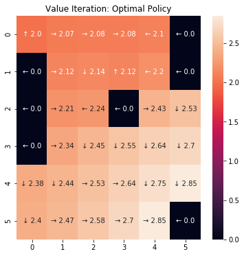

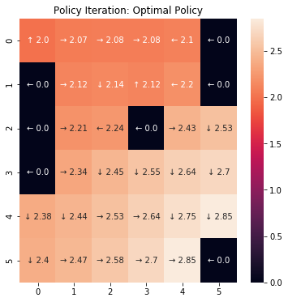

```python
gamma = 0.99
epsilon  = 0.01

# Plot optimal policy for VI
vi = ValueIteration(fltrans, flrewards, gamma, epsilon=epsilon)
vi.run()

policyarr = np.array(list(vi.policy)).reshape(flsz, flsz).astype(str)

valuearr = np.round(np.array(list(vi.V)).reshape(flsz, flsz), 2)
# np.char.replace(policyarr, '0', '←')
# np.char.replace(policyarr, '1', '↓')
# np.char.replace(policyarr, '2', '→')
# np.char.replace(policyarr, '3', '↑')
policyarr[policyarr=='0'] = '←'
policyarr[policyarr=='1'] = '↓'
policyarr[policyarr=='2'] = '→'
policyarr[policyarr=='3'] = '↑'


policyviz = (np.asarray([a+" "+str(v) for a, v in zip(policyarr.flatten(), valuearr.flatten())])).reshape(flsz,flsz)
plt.figure(figsize=(flsz,flsz))
plt.title("Value Iteration: Optimal Policy")
sns.heatmap(valuearr, annot=policyviz, fmt="")

# Plot optimal policy for PI
pi = PolicyIterationModified(fltrans, flrewards, gamma, epsilon=epsilon)
pi.run()

policyarr = np.array(list(pi.policy)).reshape(flsz, flsz).astype(str)

valuearr = np.round(np.array(list(pi.V)).reshape(flsz, flsz), 2)
# np.char.replace(policyarr, '0', '←')
# np.char.replace(policyarr, '1', '↓')
# np.char.replace(policyarr, '2', '→')
# np.char.replace(policyarr, '3', '↑')
policyarr[policyarr=='0'] = '←'
policyarr[policyarr=='1'] = '↓'
policyarr[policyarr=='2'] = '→'
policyarr[policyarr=='3'] = '↑'


policyviz = (np.asarray([a+" "+str(v) for a, v in zip(policyarr.flatten(), valuearr.flatten())])).reshape(flsz,flsz)
plt.figure(figsize=(flsz,flsz))
plt.title("Policy Iteration: Optimal Policy")
sns.heatmap(valuearr, annot=policyviz, fmt="")

# # Plot optimal policy for QL
# ql = QLearning(trans, rewards, gamma, n_iter=1000000)
# ql.run()

# policyarr = np.array(list(ql.policy)).reshape(sz, sz).astype(str)

# valuearr = np.round(np.array(list(ql.V)).reshape(sz, sz), 2)
# # np.char.replace(policyarr, '0', '←')
# # np.char.replace(policyarr, '1', '↓')
# # np.char.replace(policyarr, '2', '→')
# # np.char.replace(policyarr, '3', '↑')
# policyarr[policyarr=='0'] = '←'
# policyarr[policyarr=='1'] = '↓'
# policyarr[policyarr=='2'] = '→'
# policyarr[policyarr=='3'] = '↑'


# policyviz = (np.asarray([a+" "+str(v) for a, v in zip(policyarr.flatten(), valuearr.flatten())])).reshape(sz,sz)
# plt.figure(figsize=(sz,sz))
# plt.title("Q Learning: Optimal Policy - Size: {}x{}".format(sz,sz))
# sns.heatmap(valuearr, annot=policyviz, fmt="")
```

#### 5.3.2 Forest Management - Optimal Policy

Below section represents the optimal policies generated by the Value Iteration and Policy Iteration algorithms for Forest Management problem. C represents the cut action and W represents the wait action. Values associated with each action is also depicted. Note that although this problem has very large state space, but the optimal policy generated by the Value Iteration and Policy Iteration algorithm is extremely close.

```python
gamma =0.999
epsilon  = 0.0000001

# Plot optimal policy for VI
vi = ValueIteration(fmtrans, fmrewards, gamma, epsilon=epsilon)
vi.run()
policyarr = np.array(list(vi.policy)).reshape(fmsz).astype(str)
valuearr = np.round(np.array(list(vi.V)).reshape(fmsz), 2)

policyarr[policyarr=='0'] = 'W'
policyarr[policyarr=='1'] = 'C'
policyviz = (np.asarray([a+" "+str(v) for a, v in zip(policyarr.flatten(), valuearr.flatten())])).reshape(fmsz)

print("Value Iteration: Optimal Policy")
line=""
for val in policyviz:
    line += (" {} >".format(val))
print(line)

# Plot optimal policy for PI
pi = PolicyIterationModified(fmtrans, fmrewards, gamma, epsilon=epsilon)
pi.run()
policyarr = np.array(list(pi.policy)).reshape(fmsz).astype(str)
valuearr = np.round(np.array(list(pi.V)).reshape(fmsz), 2)
policyarr[policyarr=='0'] = 'W'
policyarr[policyarr=='1'] = 'C'
policyviz = (np.asarray([a+" "+str(v) for a, v in zip(policyarr.flatten(), valuearr.flatten())])).reshape(fmsz)

print("")
print("Policy Iteration: Optimal Policy")
line=""
for val in policyviz:
    line += (" {} >".format(val))
print(line)

# # Plot optimal policy for QL
# ql = QLearning(trans, rewards, gamma, n_iter=1000000)
# ql.run()
# print(ql.policy)
# policyarr = np.array(list(ql.policy)).reshape(sz).astype(str)

# valuearr = np.round(np.array(list(ql.V)).reshape(sz), 2)
# policyarr[policyarr=='0'] = 'W'
# policyarr[policyarr=='1'] = 'C'
# policyviz = (np.asarray([a+" "+str(v) for a, v in zip(policyarr.flatten(), valuearr.flatten())])).reshape(fmsz)

# print("")
# print("Q Learning: Optimal Policy")
# line=""
# for val in policyviz:
#     line += (" {} >".format(val))
# print(line)
```

```
Value Iteration: Optimal Policy
 W 97.12 > C 97.65 > C 97.65 > C 97.65 > C 97.65 > C 97.65 > C 97.65 > C 97.65 > C 97.65 > C 97.65 > C 97.65 > C 97.65 > C 97.65 > C 97.65 > C 97.65 > C 97.65 > C 97.65 > C 97.65 > C 97.65 > C 97.65 > C 97.65 > C 97.65 > C 97.65 > C 97.65 > C 97.65 > C 97.65 > C 97.65 > C 97.65 > C 97.65 > C 97.65 >…

Policy Iteration: Optimal Policy
 W 97.87 > C 98.4 > C 98.4 > C 98.4 > C 98.4 > C 98.4 > C 98.4 > C 98.4 > C 98.4 > C 98.4 > C 98.4 > C 98.4 > C 98.4 > C 98.4 > C 98.4 > C 98.4 > C 98.4 > C 98.4 > C 98.4 > C 98.4 > C 98.4 > C 98.4 > C 98.4 > C 98.4 > C 98.4 > C 98.4 > C 98.4 > C 98.4 > C 98.4 > C 98.4 > C 98.4 > C 98.4 > C 98.4 > C…
```

#### 5.4 Varying problem size

In this section, results of the algorithms are analyzed for the different problem sizes to understand the performance of the algorithms.

##### 5.4.1 Frozen Lake - Different problem sizes

```python
vistats = []
pistats = []

gridsizes = range(4, 50, 1)
gamma = 0.99
for sz in gridsizes:
    rmap = generate_random_map(size=sz, p=0.85)
    env = gym.make("FrozenLake-v0", desc=rmap, is_slippery = True)
    env.reset()

    states = env.observation_space.n
    actions = env.action_space.n

    trans = np.zeros((actions, states, states))
    rewards = np.zeros((states, actions))

    for state in env.env.P:
        for action in env.env.P[state]:
            for opt in env.env.P[state][action]:
                trans[action][state][opt[1]] += opt[0]
                rewards[state][action] += opt[2]


    vi = ValueIteration(trans, rewards, gamma)
    vi.run()
    time = vi.time
    maxV = np.amax(vi.V)
    iters = vi.iter
    vistats.append(['VI', sz, gamma, time, maxV, iters])

    pi = PolicyIterationModified(trans, rewards, gamma)
    pi.run()
    time = pi.time
    maxV = np.amax(pi.V)
    iters = pi.iter
    pistats.append(['PI', sz, gamma, time, maxV, iters])

#     ql = QLearning(trans, rewards, gamma, n_iter=10000)
#     ql.run()
#     qldf = ql.run_stats
#     time = ql.time
#     maxV = np.amax(ql.V)
#     iters = 0
#     qlstats.append(['QL', sz, gamma,  time, maxV, iters])
```

```python
vistatsdf = pd.DataFrame(vistats, columns=['Type', 'Size', 'Gamma',  'Time', 'MaxV', 'Iterations'])
pistatsdf = pd.DataFrame(pistats, columns=['Type', 'Size', 'Gamma',  'Time', 'MaxV', 'Iterations'])
# qlstatsdf = pd.DataFrame(qlstats, columns=['Type', 'Size', 'Gamma',  'Time', 'MaxV', 'Iterations'])
```

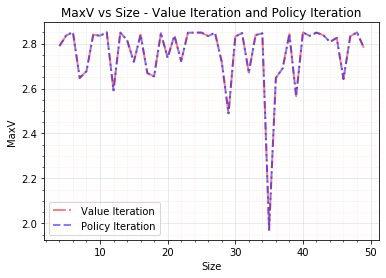

```python
fig, ax = plt.subplots()
ax.plot(vistatsdf['Size'], vistatsdf['MaxV'], color='red', label="Value Iteration", linewidth=2.0, linestyle='-.', alpha=0.5)
ax.plot(pistatsdf['Size'], pistatsdf['MaxV'], color='blue', label="Policy Iteration", linewidth=2.0, linestyle='--', alpha=0.5)
# ax.plot(qlstatsdf['Size'], qlstatsdf['MaxV'], color='green', label="Q Learning", linewidth=2.0, linestyle='--', alpha=0.5)

# ax.set_ylim([0, 5])
ax.set_title('MaxV vs Size - Value Iteration and Policy Iteration')
ax.legend(loc='best')
plt.xlabel('Size')
plt.ylabel('MaxV')
plt.minorticks_on()
plt.grid(b=True, which='major', color='k', linestyle='-', alpha=0.1)
plt.grid(b=True, which='minor', color='r', linestyle='-', alpha=0.05)
plt.show()
```

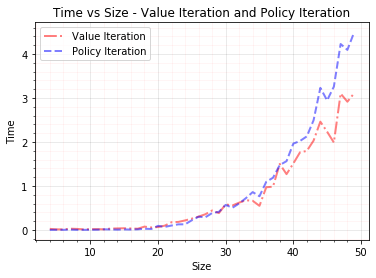

```python
fig, ax = plt.subplots()
ax.plot(vistatsdf['Size'], vistatsdf['Time'], color='red', label="Value Iteration", linewidth=2.0, linestyle='-.', alpha=0.5)
ax.plot(pistatsdf['Size'], pistatsdf['Time'], color='blue', label="Policy Iteration", linewidth=2.0, linestyle='--', alpha=0.5)
# ax.plot(qlstatsdf['Size'], qlstatsdf['Time'], color='green', label="Q Learning", linewidth=2.0, linestyle='--', alpha=0.5)

# ax.set_ylim([0, 5])
ax.set_title('Time vs Size - Value Iteration and Policy Iteration')
ax.legend(loc='best')
plt.xlabel('Size')
plt.ylabel('Time')
plt.minorticks_on()
plt.grid(b=True, which='major', color='k', linestyle='-', alpha=0.1)
plt.grid(b=True, which='minor', color='r', linestyle='-', alpha=0.05)
plt.show()
```

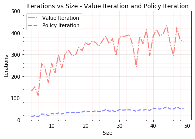

```python
fig, ax = plt.subplots()
ax.plot(vistatsdf['Size'], vistatsdf['Iterations'], color='red', label="Value Iteration", linewidth=2.0, linestyle='-.', alpha=0.5)
ax.plot(pistatsdf['Size'], pistatsdf['Iterations'], color='blue', label="Policy Iteration", linewidth=2.0, linestyle='--', alpha=0.5)
# ax.plot(qlstatsdf['Size'], qlstatsdf['Iterations'], color='green', label="Q Learning", linewidth=2.0, linestyle='--', alpha=0.5)

ax.set_ylim([0, 500])
ax.set_title('Iterations vs Size - Value Iteration and Policy Iteration')
ax.legend(loc='best')
plt.xlabel('Size')
plt.ylabel('Iterations')
plt.minorticks_on()
plt.grid(b=True, which='major', color='k', linestyle='-', alpha=0.1)
plt.grid(b=True, which='minor', color='r', linestyle='-', alpha=0.05)
plt.show()
```

#### 5.4.2 Forest Management - Analyze results of varying size

For forest management problem size was varied from 5 to 500 and noticeable difference was observed in the Max Value and number of iterations required to converge even for the smaller size of the problem. The runtime for both of the algorithms was very close until problem size was 350 after that runtime of policy iteration exponentially increase till size 500.

```python
vistats = []
pistats = []

sizes = range(4, 500, 1)
gamma = 0.99
for sz in sizes:
    trans, rewards = forest(S=sz)

    vi = ValueIteration(trans, rewards, gamma)
    vi.run()
    time = vi.time
    maxV = np.amax(vi.V)
    iters = vi.iter
    vistats.append(['VI', sz, gamma, time, maxV, iters])

    pi = PolicyIterationModified(trans, rewards, gamma)
    pi.run()
    time = pi.time
    maxV = np.amax(pi.V)
    iters = pi.iter
    pistats.append(['PI', sz, gamma, time, maxV, iters])

#     ql = QLearning(trans, rewards, gamma, n_iter=10000)
#     ql.run()
#     qldf = ql.run_stats
#     time = ql.time
#     maxV = np.amax(ql.V)
#     iters = 0
#     qlstats.append(['QL', sz, gamma,  time, maxV, iters])
```

```python
vistatsdf = pd.DataFrame(vistats, columns=['Type', 'Size', 'Gamma',  'Time', 'MaxV', 'Iterations'])
pistatsdf = pd.DataFrame(pistats, columns=['Type', 'Size', 'Gamma',  'Time', 'MaxV', 'Iterations'])
# qlstatsdf = pd.DataFrame(qlstats, columns=['Type', 'Size', 'Gamma',  'Time', 'MaxV', 'Iterations'])
```

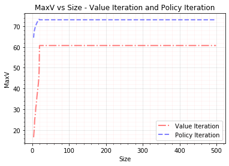

```python
fig, ax = plt.subplots()
ax.plot(vistatsdf['Size'], vistatsdf['MaxV'], color='red', label="Value Iteration", linewidth=2.0, linestyle='-.', alpha=0.5)
ax.plot(pistatsdf['Size'], pistatsdf['MaxV'], color='blue', label="Policy Iteration", linewidth=2.0, linestyle='--', alpha=0.5)
# ax.plot(qlstatsdf['Size'], qlstatsdf['MaxV'], color='green', label="Q Learning", linewidth=2.0, linestyle='--', alpha=0.5)

# ax.set_ylim([0, 5])
ax.set_title('MaxV vs Size - Value Iteration and Policy Iteration')
ax.legend(loc='best')
plt.xlabel('Size')
plt.ylabel('MaxV')
plt.minorticks_on()
plt.grid(b=True, which='major', color='k', linestyle='-', alpha=0.1)
plt.grid(b=True, which='minor', color='r', linestyle='-', alpha=0.05)
plt.show()
```

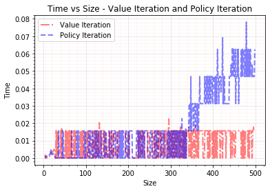

```python
fig, ax = plt.subplots()
ax.plot(vistatsdf['Size'], vistatsdf['Time'], color='red', label="Value Iteration", linewidth=2.0, linestyle='-.', alpha=0.5)
ax.plot(pistatsdf['Size'], pistatsdf['Time'], color='blue', label="Policy Iteration", linewidth=2.0, linestyle='--', alpha=0.5)
# ax.plot(qlstatsdf['Size'], qlstatsdf['Time'], color='green', label="Q Learning", linewidth=2.0, linestyle='--', alpha=0.5)

# ax.set_ylim([0, 5])
ax.set_title('Time vs Size - Value Iteration and Policy Iteration')
ax.legend(loc='best')
plt.xlabel('Size')
plt.ylabel('Time')
plt.minorticks_on()
plt.grid(b=True, which='major', color='k', linestyle='-', alpha=0.1)
plt.grid(b=True, which='minor', color='r', linestyle='-', alpha=0.05)
plt.show()
```

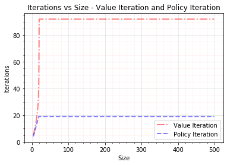

```python
fig, ax = plt.subplots()
ax.plot(vistatsdf['Size'], vistatsdf['Iterations'], color='red', label="Value Iteration", linewidth=2.0, linestyle='-.', alpha=0.5)
ax.plot(pistatsdf['Size'], pistatsdf['Iterations'], color='blue', label="Policy Iteration", linewidth=2.0, linestyle='--', alpha=0.5)
#ax.plot(qlstatsdf['Size'], qlstatsdf['Iterations'], color='green', label="Q Learning", linewidth=2.0, linestyle='--', alpha=0.5)

# ax.set_ylim([0, 500])
ax.set_title('Iterations vs Size - Value Iteration and Policy Iteration')
ax.legend(loc='best')
plt.xlabel('Size')
plt.ylabel('Iterations')
plt.minorticks_on()
plt.grid(b=True, which='major', color='k', linestyle='-', alpha=0.1)
plt.grid(b=True, which='minor', color='r', linestyle='-', alpha=0.05)
plt.show()
```

### 6. Q Learning

#### 6.1 Optimal value of Discount Factor (Gamma)

##### 6.1.1 Frozen Lake - Optimal value of Discount Factor (Gamma)

```python
qlstats = []
gammas = np.arange(0.1, 0.99, 0.04)

for gamma in gammas:
    ql = QLearning(fltrans, flrewards, gamma, n_iter=100000)
    ql.run()
    time = ql.time
    maxV = np.amax(ql.V)
    qlstats.append(['QL', flsz, gamma, time, maxV])

dfqlfl = pd.DataFrame(qlstats, columns=['Type', 'Size', 'Gamma',  'Time', 'MaxV'])
```

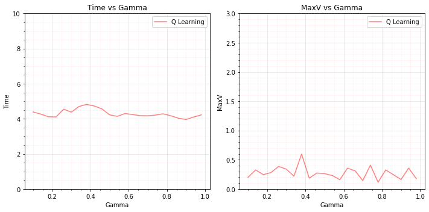

```python
fig, axs = plt.subplots(nrows=1, ncols=2, figsize=(10,5));
sns.lineplot(dfqlfl['Gamma'], dfqlfl['Time'], linestyle='-.', label = "Q Learning", ax=axs[0], alpha=0.5, color='red')
axs[0].set_title('Time vs Gamma')
axs[0].set_ylim([0,10])

sns.lineplot(dfqlfl['Gamma'], dfqlfl['MaxV'], linestyle='-.', label = "Q Learning", ax=axs[1], alpha=0.5, color='red')
axs[1].set_title('MaxV vs Gamma')
axs[1].set_ylim([0,3])

for ax in axs.flat:
    ax.legend(loc='best')
    ax.minorticks_on()
    ax.grid(b=True, which='major', color='k', linestyle='-', alpha=0.1)
    ax.grid(b=True, which='minor', color='r', linestyle='-', alpha=0.05)
fig.tight_layout()
```

##### 6.1.2 Forest Management - Optimal value of Discount Factor (Gamma)

```python
qlstats = []

gammas = np.arange(0.1, 0.99, 0.04)

for gamma in gammas:
    ql = QLearning(fmtrans, fmrewards, gamma, n_iter=100000)
    ql.run()
    time = ql.time
    maxV = np.amax(ql.V)
    qlstats.append(['QL', fmsz, gamma, time, maxV])

dfqlfm = pd.DataFrame(qlstats, columns=['Type', 'Size', 'Gamma',  'Time', 'MaxV'])
```

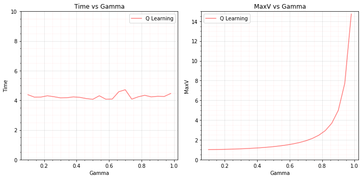

```python
fig, axs = plt.subplots(nrows=1, ncols=2, figsize=(10,5));

sns.lineplot(dfqlfm['Gamma'], dfqlfm['Time'], linestyle='-.', label = "Q Learning", ax=axs[0], alpha=0.5, color='red')
axs[0].set_title('Time vs Gamma')
axs[0].set_ylim([0,10])

sns.lineplot(dfqlfm['Gamma'], dfqlfm['MaxV'], linestyle='-.', label = "Q Learning", ax=axs[1], alpha=0.5, color='red')
axs[1].set_title('MaxV vs Gamma')
axs[1].set_ylim([0,15])

for ax in axs.flat:
    ax.legend(loc='best')
    ax.minorticks_on()
    ax.grid(b=True, which='major', color='k', linestyle='-', alpha=0.1)
    ax.grid(b=True, which='minor', color='r', linestyle='-', alpha=0.05)
fig.tight_layout()
```

For frozen lake problem, value of gamma for Q Learning problem did not impact much. Both runtime and max value was consistent for the entire range of gamma. Unlike the forest management problem, max value for the forest management problem increased with the increase in the gamma value. High max value is achieved when value of gamma was 0.99. On the other hand, runtime for each iteration with different value of gamma remained consistent.

#### 6.2 Optimal Number Iterations

In this step, Q Learning algorithm is tuned to optimal number of iterations by implementation n_iter parameter over the range of 10000 – 1000000. It is expected that with increase in the number of iterations should increase the runtime of Q Learning algorithm, but the max value should flatten out at certain threshold.

##### 6.2.1 Frozen Lake - Optimal Number Iterations

```python
qlstats = []

gamma = 0.99
niters = [10000, 50000, 100000, 500000, 1000000]

for niter in niters:
    ql = QLearning(fltrans, flrewards, gamma, n_iter=niter)
    ql.run()
    time = ql.time
    maxV = np.amax(ql.V)
    qlstats.append(['QL', sz, niter, time, maxV])

dfqlfliter = pd.DataFrame(qlstats, columns=['Type', 'Size', 'NIter',  'Time', 'MaxV'])
```

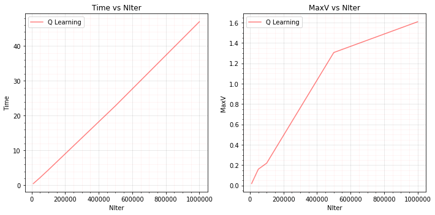

```python
fig, axs = plt.subplots(nrows=1, ncols=2, figsize=(10,5));
sns.lineplot(dfqlfliter['NIter'], dfqlfliter['Time'], linestyle='-.', label = "Q Learning", ax=axs[0], alpha=0.5, color='red')
axs[0].set_title('Time vs NIter')

sns.lineplot(dfqlfliter['NIter'], dfqlfliter['MaxV'], linestyle='-.', label = "Q Learning", ax=axs[1], alpha=0.5, color='red')
axs[1].set_title('MaxV vs NIter')

for ax in axs.flat:
    ax.legend(loc='best')
    ax.minorticks_on()
    ax.grid(b=True, which='major', color='k', linestyle='-', alpha=0.1)
    ax.grid(b=True, which='minor', color='r', linestyle='-', alpha=0.05)
fig.tight_layout()
```

##### 6.2.2 Forest Management - Optimal Number Iterations

```python
qlstats = []

gamma = 0.99
niters = [10000, 50000, 100000, 500000, 1000000]

for niter in niters:
    ql = QLearning(fmtrans, fmrewards, gamma, n_iter=niter)
    ql.run()
    time = ql.time
    maxV = np.amax(ql.V)
    qlstats.append(['QL', sz, niter, time, maxV])

dfqlfmiter = pd.DataFrame(qlstats, columns=['Type', 'Size', 'NIter',  'Time', 'MaxV'])
```

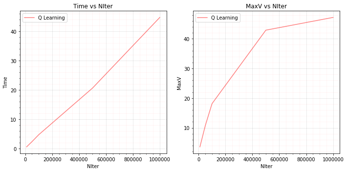

```python
fig, axs = plt.subplots(nrows=1, ncols=2, figsize=(10,5));
sns.lineplot(dfqlfmiter['NIter'], dfqlfmiter['Time'], linestyle='-.', label = "Q Learning", ax=axs[0], alpha=0.5, color='red')
axs[0].set_title('Time vs NIter')

sns.lineplot(dfqlfmiter['NIter'], dfqlfmiter['MaxV'], linestyle='-.', label = "Q Learning", ax=axs[1], alpha=0.5, color='red')
axs[1].set_title('MaxV vs NIter')

for ax in axs.flat:
    ax.legend(loc='best')
    ax.minorticks_on()
    ax.grid(b=True, which='major', color='k', linestyle='-', alpha=0.1)
    ax.grid(b=True, which='minor', color='r', linestyle='-', alpha=0.05)
fig.tight_layout()
```

For frozen lake problem, the max value linearly increases as number of iterations increase from 10000 but after 500000 iteration max value starts to plateau out until iterations reaches 1000000. As expected, runtime of the Q Learning algorithm linearly increases with increase in the number of iterations. Irrespective of the size of the problem, graphs of the Q Learning algorithm on Forest Management matches closely with the graphs of Frozen Lake problem. Although max value is at different scale but even for Forest Management problem, max value starts to plateau at 500000 iterations. Runtime increases linearly with the increase in the number of iterations.

#### 6.3 Exploration vs Exploitation & Optimal Policy

Code in this section was adapted from https://python-data-science.readthedocs.io/en/latest/reinforcement.html

```python
action_size = flenv.action_space.n
state_size = flenv.observation_space.n
qtable = np.zeros((state_size, action_size))

# define hyperparameters ----------
total_episodes = 15000        # Total episodes
learning_rate = 0.7           # Learning rate
max_steps = 100000             # Max steps per episode
gamma = 0.9                  # Discounting rate

# Exploration parameters
epsilon = 0.1                 # Exploration rate
max_epsilon = 1.0             # Exploration probability at start
min_epsilon = 0.00001            # Minimum exploration probability
decay_rate = 0.005             # Exponential decay rate for exploration prob

# List of rewards
rewards = []

# 2 For life or until learning is stopped
for episode in range(total_episodes):
    # Reset the environment
    state = flenv.reset()
    step = 0
    done = False
    total_rewards = 0

    for step in range(max_steps):
        # 3. Choose an action a in the current world state (s)
        ## First we randomize a number
        exp_exp_tradeoff = random.uniform(0, 1)

        ## If this number > greater than epsilon --> exploitation (taking the biggest Q value for this state)
        if exp_exp_tradeoff > epsilon:
            action = np.argmax(qtable[state,:])

        # Else doing a random choice --> exploration
        else:
            action = flenv.action_space.sample()

        # Take the action (a) and observe the outcome state(s') and reward (r)
        new_state, reward, done, info = flenv.step(action)

        # Update Q(s,a):= Q(s,a) + lr [R(s,a) + gamma * max Q(s',a') - Q(s,a)]
        # qtable[new_state,:] : all the actions we can take from new state
        qtable[state, action] = qtable[state, action] + learning_rate * (reward + gamma * np.max(qtable[new_state, :]) - qtable[state, action])

        total_rewards += reward

        # Our new state is state
        state = new_state

        # If done (if we're dead) : finish episode
        if done == True:
            break

    # Reduce epsilon (because we need less and less exploration)
    epsilon = min_epsilon + (max_epsilon - min_epsilon)*np.exp(-decay_rate*episode)
    rewards.append(total_rewards)

print ("Score over time: " +  str(sum(rewards)/total_episodes))
print(qtable)
```

```
Score over time: 0.0
[[0. 0. 0. 0.]
 [0. 0. 0. 0.]
 [0. 0. 0. 0.]
 [0. 0. 0. 0.]
 [0. 0. 0. 0.]
 [0. 0. 0. 0.]
 [0. 0. 0. 0.]
 [0. 0. 0. 0.]
 [0. 0. 0. 0.]
 [0. 0. 0. 0.]
 [0. 0. 0. 0.]
 [0. 0. 0. 0.]
 [0. 0. 0. 0.]
 [0. 0. 0. 0.]
 [0. 0. 0. 0.]
 [0. 0. 0. 0.]
 [0. 0. 0. 0.]
 [0. 0. 0. 0.]
 [0. 0. 0. 0.]
 [0. 0. 0. 0.]
 [0. 0. 0. 0.]
 [0. 0. 0. 0.]
 [0. 0. 0. 0.]
 [0. 0. 0. 0.]
 [0. 0. 0. 0.]
 [0. 0. 0. 0.]
 [0. 0. 0. 0.]
 [0. 0. 0. 0.]
 [0. 0. 0. 0.]
 [0. 0. 0. 0.]
 [0. 0. 0. 0.]
 [0. 0. 0. 0.]
 [0. 0. 0. 0.]
 [0. 0. 0. 0.]
 [0. 0. 0. 0.]
 [0. 0. 0. 0.]]
```

##### 6.3.2 Frozen Lake – Optimal Policy

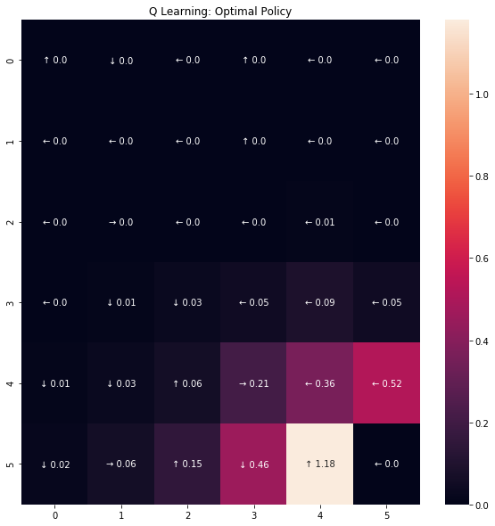

```python
gamma = 0.80

# Plot optimal policy for QL
ql = QLearning(fltrans, flrewards, gamma, n_iter=1000000)
ql.run()

policyarr = np.array(list(ql.policy)).reshape(flsz, flsz).astype(str)

valuearr = np.round(np.array(list(ql.V)).reshape(flsz, flsz), 2)
# np.char.replace(policyarr, '0', '←')
# np.char.replace(policyarr, '1', '↓')
# np.char.replace(policyarr, '2', '→')
# np.char.replace(policyarr, '3', '↑')
policyarr[policyarr=='0'] = '←'
policyarr[policyarr=='1'] = '↓'
policyarr[policyarr=='2'] = '→'
policyarr[policyarr=='3'] = '↑'


policyviz = (np.asarray([a+" "+str(v) for a, v in zip(policyarr.flatten(), valuearr.flatten())])).reshape(flsz,flsz)
plt.figure(figsize=(10,10))
plt.title("Q Learning: Optimal Policy")
sns.heatmap(valuearr, annot=policyviz, fmt="")
```

##### 6.3.3 Fores Management – Optimal Policy

```python
gamma = 0.80

# Plot optimal policy for QL
ql = QLearning(fmtrans, fmrewards, gamma, n_iter=1000000)
ql.run()

policyarr = np.array(list(ql.policy)).reshape(fmsz).astype(str)
valuearr = np.round(np.array(list(ql.V)).reshape(fmsz), 2)
policyarr[policyarr=='0'] = 'W'
policyarr[policyarr=='1'] = 'C'
policyviz = (np.asarray([a+" "+str(v) for a, v in zip(policyarr.flatten(), valuearr.flatten())])).reshape(fmsz)

print("")
print("Q Learning: Optimal Policy")
line=""
for val in policyviz:
    line += (" {} >".format(val))
print(line)
```

```
Q Learning: Optimal Policy
 W 2.1 > C 2.68 > C 2.67 > C 1.58 > C 0.22 > W 0.01 > C 0.05 > W 0.0 > W 0.0 > W 0.01 > W 0.02 > C 0.2 > C 0.03 > C 0.06 > C 0.07 > W 0.01 > W 0.01 > C 0.15 > W 0.01 > W 0.01 > C 0.12 > C 0.07 > W 0.01 > W 0.01 > C 0.18 > W 0.0 > W 0.01 > C 0.12 > C 0.04 > W 0.0 > W 0.01 > W 0.02 > W 0.03 > C 0.2 > …
```

[1] https://blog.csdn.net/songrotek/article/details/51378582  
[2] https://medium.com/@ranko.mosic/reinforcement-learning-based-trading-application-at-jp-morgan-chase-f829b8ec54f2  
[3] https://gym.openai.com/envs/FrozenLake-v0/  
[4] https://python-data-science.readthedocs.io/en/latest/reinforcement.html